# Linear Discriminant Analysis

Fisher’s Iris Data

## Background

Goal: Find the linear combination of original variables that provide the best possible separation between groups.

- Developed by R. A. Fisher in 1936 (hence, the appropriateness of his Iris data as an example)
- Dimension reduction method
- Optimal when explanatory variables have normal distribution.

## Load libraries

```r
library(tidyverse)
library(skimr) # skim
library(psych) # pairs.panels
library(MASS)  # lda
```

## Data

```r
data(iris)  # data set built into base R
head(iris)
```

```
##   Sepal.Length Sepal.Width Petal.Length Petal.Width Species
## 1          5.1         3.5          1.4         0.2  setosa
## 2          4.9         3.0          1.4         0.2  setosa
## 3          4.7         3.2          1.3         0.2  setosa
## 4          4.6         3.1          1.5         0.2  setosa
## 5          5.0         3.6          1.4         0.2  setosa
## 6          5.4         3.9          1.7         0.4  setosa
```

```r
skim(iris)
```

Data summary

| Name | iris |
| --- | --- |
| Number of rows | 150 |
| Number of columns | 5 |
| _______________________ |  |
| Column type frequency: |  |
| factor | 1 |
| numeric | 4 |
| ________________________ |  |
| Group variables | None |

**Variable type: factor**

| skim_variable | n_missing | complete_rate | ordered | n_unique | top_counts |
| --- | --- | --- | --- | --- | --- |
| Species | 0 | 1 | FALSE | 3 | set: 50, ver: 50, vir: 50 |

**Variable type: numeric**

| skim_variable | n_missing | complete_rate | mean | sd | p0 | p25 | p50 | p75 | p100 | hist |
| --- | --- | --- | --- | --- | --- | --- | --- | --- | --- | --- |
| Sepal.Length | 0 | 1 | 5.84 | 0.83 | 4.3 | 5.1 | 5.80 | 6.4 | 7.9 | ▆▇▇▅▂ |
| Sepal.Width | 0 | 1 | 3.06 | 0.44 | 2.0 | 2.8 | 3.00 | 3.3 | 4.4 | ▁▆▇▂▁ |
| Petal.Length | 0 | 1 | 3.76 | 1.77 | 1.0 | 1.6 | 4.35 | 5.1 | 6.9 | ▇▁▆▇▂ |
| Petal.Width | 0 | 1 | 1.20 | 0.76 | 0.1 | 0.3 | 1.30 | 1.8 | 2.5 | ▇▁▇▅▃ |

Type `?iris` in the console to view description.

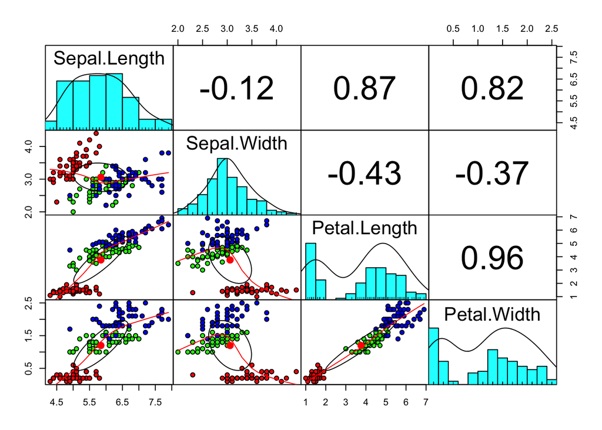

```r
pairs.panels(iris[1:4],
             gap = 0,
             bg = c("red", "green", "blue")[iris$Species],
             pch = 21)
```

## Create training (70%) and testing (30%) data

```r
set.seed(123)
ind <- sample(2, nrow(iris),
              replace = TRUE,
              prob = c(0.7, 0.3))
training <- iris[ind==1,]
testing <- iris[ind==2,]
```

## Linear discriminant analysis

Using `.` for the right side of the model formula tells R to use all available explanatory variables in the data set.

```r
linear <- lda(Species ~ ., training)
linear
```

```
## Call:
## lda(Species ~ ., data = training)
##
## Prior probabilities of groups:
##     setosa versicolor  virginica
##  0.3301887  0.3396226  0.3301887
##
## Group means:
##            Sepal.Length Sepal.Width Petal.Length Petal.Width
## setosa         4.940000    3.405714     1.445714   0.2428571
## versicolor     5.908333    2.766667     4.202778   1.3027778
## virginica      6.634286    2.925714     5.565714   2.0428571
##
## Coefficients of linear discriminants:
##                     LD1        LD2
## Sepal.Length  0.5329061  0.2942187
## Sepal.Width   2.1256776  1.9325511
## Petal.Length -1.9624296 -1.1434715
## Petal.Width  -3.5611214  3.0035717
##
## Proportion of trace:
##   LD1   LD2
## 0.993 0.007
```

The “prior probabilities of groups” are just the sample proportions:

```r
training %>% group_by(Species) %>% summarize(sample_proportion = n()/length(training[,1]))
```

```
## # A tibble: 3 × 2
##   Species    sample_proportion
##   <fct>                  <dbl>
## 1 setosa                 0.330
## 2 versicolor             0.340
## 3 virginica              0.330
```

## Group separation

The entries in `LD1` and `LD2` are the coefficients of the linear combinations of explanatory variables that achieve maximum separation of the data between groups. The linear discriminant functions are scaled to have mean 0 and variance 1 in the training data set.

The percentage separation achieved by the first discriminant function is 99.3% and second is 0.7%

We can plot stacked histograms of the values of the first discriminant function for the training data set and visualize the degree of separation.

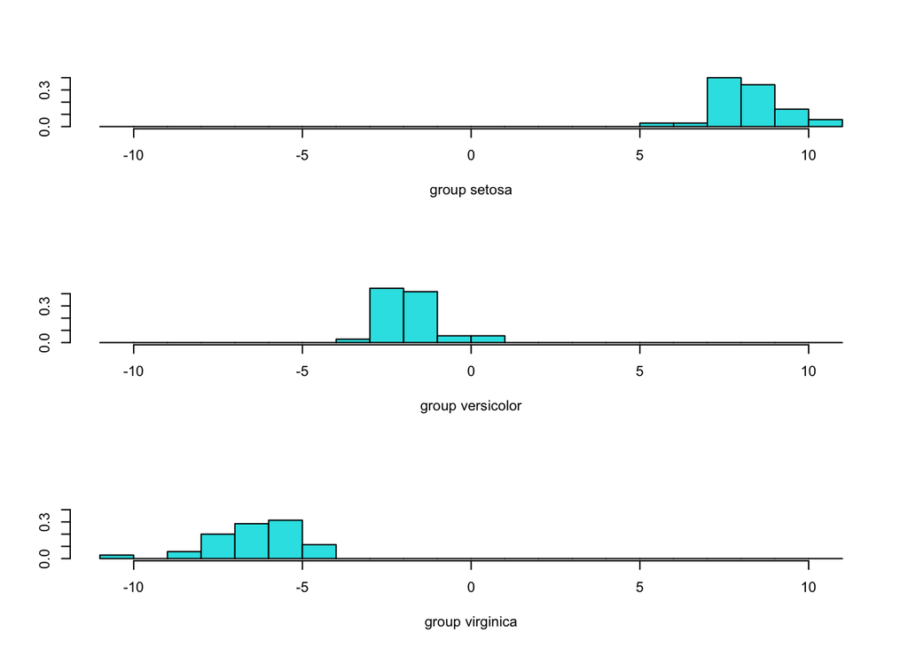

```r
p <- predict(linear, training)
ldahist(data = p$x[,1], g = training$Species)
```

The second discriminant function does not separate the groups well.

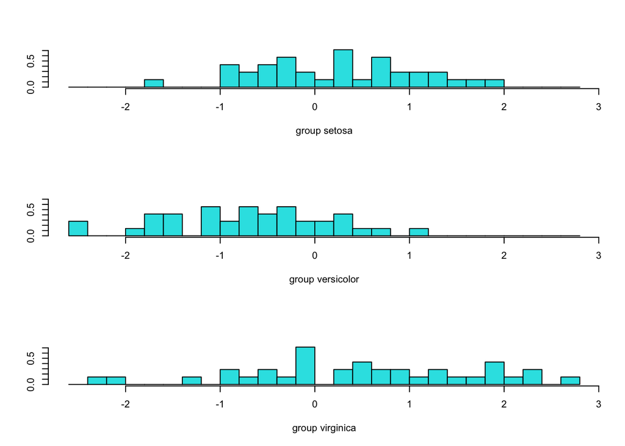

```r
ldahist(data = p$x[,2], g = training$Species)
```

To view the separation in two dimensions:

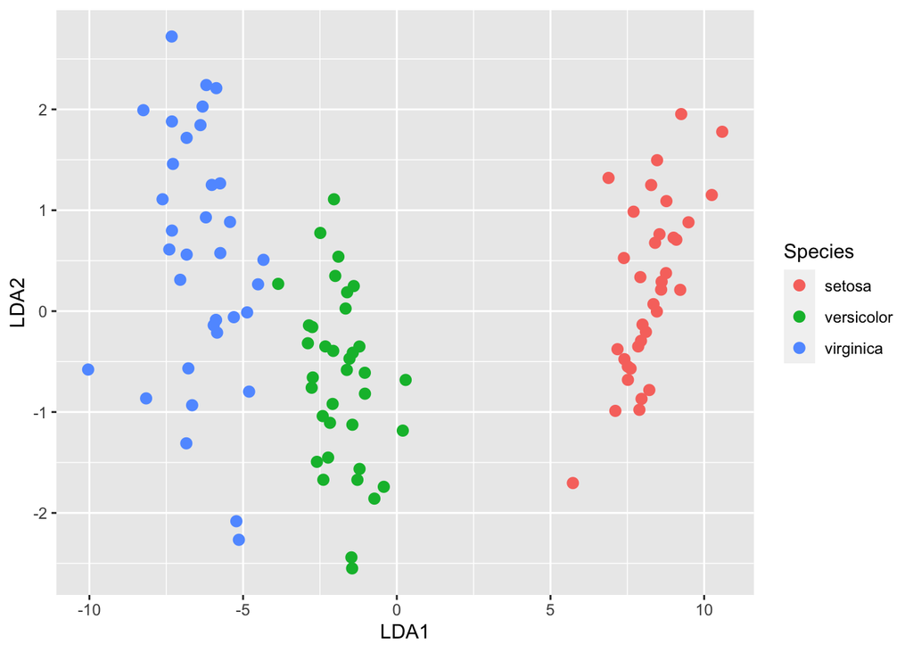

```r
# Create data frame with species, LDA1, LDA2 values in training data set
newdata <- data.frame(Species = training[,5], lda = p$x)
ggplot(newdata) +
  geom_point(aes(x = lda.LD1, y = lda.LD2, colour = Species), size = 2.5) +
  labs(x = "LDA1", y = "LDA2")
```

## Prediction accuracy

Compare actual group to predicted group on training data:

```r
p1 <- predict(linear, training)$class
tab1 <- table(Predicted = p1, Actual = training$Species)
tab1
```

```
##             Actual
## Predicted    setosa versicolor virginica
##   setosa         35          0         0
##   versicolor      0         36         0
##   virginica       0          0        35
```

The number correctly classified in the training data set is 106, which gives a classification error rate of 0.

```r
p2 <- predict(linear, testing)$class
tab2 <- table(Predicted = p2, Actual = testing$Species)
```

## References

Example taken from “Linear Discriminant Analysis in R” by finnstats in R bloggers: https://www.r-bloggers.com/2021/05/linear-discriminant-analysis-in-r/.